# Aidan's Python Cheat Sheet

*A reference guide for code I regularly need to facilitate the Big Switch from Matlab*

## Outline:

- Time series data (loading, plotting, and exploring example sedimnt core data
- Spatial data (loading, visualising, and manipulating example oceanographic data
- Climate model output data (load and visualise CMIP5 model output)

**Note: Where possible/I remember, I try to follow the [PEP 8 Style Guide for Python](https://www.python.org/dev/peps/pep-0008/#a-foolish-consistency-is-the-hobgoblin-of-little-minds)**

## Part 1- Time Series Data

- in the folder /datasets are 4 .tab data files downloaded from Pangaea.de
- they are from [Bender et al. 2013](https://doi.pangaea.de/10.1594/PANGAEA.818089)
- load the data, visualise the data, do some exploratory data analysis

```python
import numpy as np
import pandas as pd
import matplotlib.pyplot as plt
import seaborn as sns

from matplotlib.ticker import AutoMinorLocator
```

### Import Data

- Using pandas read_csv function with the delimiter (sep=) at /t (tab)
- Set the index to age (the second column)
- current I'm having to open the file manually and check which row the headers are on (pangea.de formatted data can have a lot of metadata with varying numbers of rows...)
- *there must be a way to get around this*

```python
Ca_Ti = pd.read_csv('datasets/GeoB13801-2_Ca-Ti_ratio.tab',sep='\t',header=(15))
O18_C13 = pd.read_csv('datasets/GeoB13801-2_d18O_d13C.tab',sep='\t',header=(15))
grain_size = pd.read_csv('datasets/GeoB13801-2_sand_silt_clay.tab',sep='\t',header=(19))
toc_caco3 = pd.read_csv('datasets/GeoB13801-2_TOC_CaCO3.tab',sep='\t',header=(15))

Ca_Ti.head() # display first few rows
O18_C13.head()
grain_size
```

|  | Depth [m] | Age [ka BP] | >63 µm [%] (bulk) | 63-4 µm [%] (bulk) | <4 µm [%] (bulk) | >63 µm [%] (terrigenous) | 63-4 µm [%] (terrigenous) | <4 µm [%] (terrigenous) |
| --- | --- | --- | --- | --- | --- | --- | --- | --- |
| 0 | 0.01 | -0.034 | 31.417 | 64.45 | 4.133 | 40.780 | 46.22 | 13.000 |
| 1 | 0.11 | 0.217 | 20.750 | 73.57 | 5.680 | 36.016 | 46.98 | 17.004 |
| 2 | 0.21 | 0.450 | 33.799 | 61.78 | 4.421 | 57.435 | 31.46 | 11.105 |
| 3 | 0.31 | 0.520 | 33.047 | 62.41 | 4.543 | 60.388 | 29.33 | 10.282 |
| 4 | 0.41 | 0.594 | 45.123 | 50.29 | 4.587 | 70.471 | 23.21 | 6.319 |
| ... | ... | ... | ... | ... | ... | ... | ... | ... |
| 91 | 9.11 | 10.470 | 61.448 | 27.83 | 10.722 | 71.175 | 23.62 | 5.205 |
| 92 | 9.21 | 10.501 | 32.242 | 49.18 | 18.578 | 62.172 | 28.08 | 9.748 |
| 93 | 9.31 | 10.532 | 44.727 | 41.95 | 13.323 | 39.756 | 50.49 | 9.754 |
| 94 | 9.41 | 10.563 | 74.065 | 19.85 | 6.085 | 48.901 | 43.70 | 7.399 |
| 95 | 9.51 | 10.593 | 39.987 | 40.72 | 19.293 | 78.788 | 15.80 | 5.412 |

96 rows × 8 columns

```python
Ca_Ti.set_index('Age [ka BP]',drop=False,inplace=True)
O18_C13.set_index('Age [ka BP]',drop=False,inplace=True)
grain_size.set_index('Age [ka BP]',drop=False,inplace=True)
toc_caco3.set_index('Age [ka BP]',drop=False,inplace=True)
```

### Visualize the Data

- load a colorpallete from seaborn

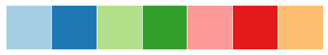

```python
colors = sns.color_palette('Paired',7)
sns.palplot(colors)
```

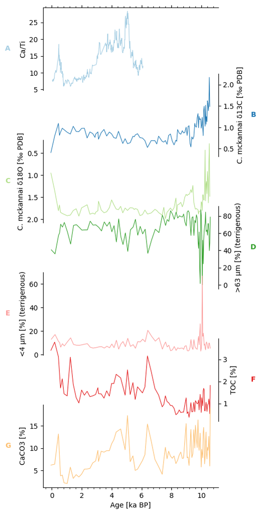

```python
plt.rcParams.update(plt.rcParamsDefault)
fig,axes = plt.subplots(nrows = 7, figsize=(5,11), sharex=True)
sns.set_context('paper',font_scale=1)

lw = .8
ms = 1.5

sns.despine(ax=axes[0],right=True,bottom=True,top=False)
sns.despine(ax=axes[-1],right=True,bottom=False,top=True)
axes[0].patch.set_alpha(0)
axes[-1].patch.set_alpha(0)


for i,ax in enumerate(axes[1:-1]):
    ax.patch.set_alpha(0)
    ax.xaxis.set_visible(False)
    if i%2==1:
        sns.despine(ax=ax,bottom=True)
    else:
        sns.despine(ax=ax,left=True, right=False, bottom=True, top= True)
        ax.yaxis.set_label_position("right")

Ca_Ti.plot(ax=axes[0],x=Ca_Ti.columns[1], y="Ca/Ti", color=colors[0], lw=lw)
axes[0].set_ylabel("Ca/Ti")

colz = O18_C13.columns
O18_C13.plot(ax=axes[1],x=O18_C13.columns[1], y=colz[2], color=colors[1], lw=lw)
axes[1].set_ylabel(colz[2])

O18_C13.plot(ax=axes[2],x=O18_C13.columns[1], y=colz[3], color=colors[2], lw=lw)
axes[2].set_ylabel(colz[3])

colz = grain_size.columns
grain_size.plot(ax=axes[3],x=colz[1], y=colz[5], color=colors[3], lw=lw)
axes[3].set_ylabel(colz[5])

grain_size.plot(ax=axes[4],x=colz[1], y=colz[7], color=colors[4], lw=lw)
axes[4].set_ylabel(colz[7])

colz = toc_caco3.columns
toc_caco3.plot(ax=axes[5],x=colz[1], y=colz[2], color=colors[5], lw=lw)
axes[5].set_ylabel(colz[2])

toc_caco3.plot(ax=axes[6],x=colz[1], y=colz[3], color=colors[6], lw=lw)
axes[6].set_ylabel(colz[3])

# add a:f
labels=['A','C','E','G']
axs=[0,2,4,6]

for i in np.arange(0,4):
    axes[axs[i]].annotate(labels[i],xy=(-.2,.5),
        xycoords='axes fraction',horizontalalignment='center',
        verticalalignment='center',size=10,fontweight='bold',
                         color=colors[axs[i]])

labels=['B','D','F']
axs=[1,3,5]

for i in np.arange(0,3):
    axes[axs[i]].annotate(labels[i],xy=(1+.2,.5),
        xycoords='axes fraction',horizontalalignment='center',
        verticalalignment='center',size=10,fontweight='bold',
                         color=colors[axs[i]])

axes[0].xaxis.set_minor_locator(AutoMinorLocator(5))
axes[0].xaxis.set_label_position("top")
axes[0].set_xlabel('CCSF Splice Depth (m)')
axes[2].invert_yaxis()
axis=axes[-1]
axis.xaxis.set_minor_locator(AutoMinorLocator(5))
axis.set_xlabel(colz[1])
axis = axes[0]
axis.set_xlabel(colz[1])


plt.subplots_adjust(hspace=-.2,top=.94,bottom=.07,right=.85,left=.15)

for ax in axes:
    ax.get_legend().remove()

#fig.savefig(figure_path+'counts.png',dpi=700)
```

## Now do some more data exploring

- define a function to return the r^2
- plot scatters and heatmaps?

```python
def r2(x, y):
    return stats.pearsonr(x, y)[0] **2
```

Make a dataframe with all the data on a common x-scale... probably better ways of doing this...

```python
# find which table has lowest res
reso = np.zeros((4,1))
reso[0] = Ca_Ti['Depth [m]'].diff().mean()
reso[1] = O18_C13['Depth [m]'].diff().mean()
reso[2] = grain_size['Depth [m]'].diff().mean()
reso[3] = toc_caco3['Depth [m]'].diff().mean()
print(reso)
```

```
[[0.01094801]
 [0.09690722]
 [0.1       ]
 [0.11046512]]
```

```python
# make new dataframe with Ca_Ti
#all_data = toc_caco3.copy(deep=True) # new dataframe DEEP COPY (independent of original)
left = toc_caco3.iloc[:,:].copy(deep=True)
right = O18_C13.iloc[:,[0,2,3]].copy(deep=True)
all_data = pd.merge_asof(left,right,on="Depth [m]", tolerance=0.1, direction='nearest')

left = all_data
right = grain_size.iloc[:,[0,5,6,7]].copy(deep=True)
all_data = pd.merge_asof(left,right,on="Depth [m]", tolerance=0.02, direction='nearest')

left = all_data
right =Ca_Ti.iloc[:,[0,2]].copy(deep=True)
all_data = pd.merge_asof(left,right,on="Depth [m]", tolerance=0.05, direction='nearest')




all_data.set_index("Depth [m]")

# normalize the columns to mean=0 std=1 (aka z-score)
all_data_norm = all_data.copy(deep=True)
for columns in all_data.iloc[:,2:].columns:
    all_data_norm[columns] = (all_data[columns]-all_data[columns].mean())/all_data[columns].std()
all_data_norm
```

|  | Depth [m] | Age [ka BP] | TOC [%] | CaCO3 [%] | C. mckannai δ13C [‰ PDB] | C. mckannai δ18O [‰ PDB] | >63 µm [%] (terrigenous) | 63-4 µm [%] (terrigenous) | <4 µm [%] (terrigenous) | Ca/Ti |
| --- | --- | --- | --- | --- | --- | --- | --- | --- | --- | --- |
| 0 | 0.0 | -0.059 | 3.010714 | -0.758897 | -1.844561 | -2.139376 | -1.668984 | 1.832524 | 1.022625 | -1.022398 |
| 1 | 0.1 | 0.192 | 3.555293 | -0.705662 | -0.498063 | -0.863111 | -1.998342 | 1.902532 | 1.986670 | -0.664308 |
| 2 | 0.2 | 0.443 | 2.587797 | 1.207707 | 0.535296 | 0.602825 | -0.517544 | 0.472896 | 0.566365 | 0.301879 |
| 3 | 0.4 | 0.582 | 0.531144 | -1.437716 | -0.191883 | 0.718557 | 0.383696 | -0.287058 | -0.585963 | -0.435617 |
| 4 | 0.5 | 0.700 | 1.136553 | -1.392086 | 0.142132 | 0.805356 | 0.148915 | -0.240079 | 0.108901 | -0.617186 |
| ... | ... | ... | ... | ... | ... | ... | ... | ... | ... | ... |
| 82 | 9.1 | 10.467 | -0.514563 | 0.373971 | 1.561696 | 0.030596 | 0.432367 | -0.249291 | -0.854181 | NaN |
| 83 | 9.2 | 10.498 | -0.188685 | 1.063493 | 2.107950 | -2.836982 | -0.190053 | 0.161545 | 0.239639 | NaN |
| 84 | 9.3 | 10.529 | -0.440697 | -0.031349 | 4.289486 | -4.290060 | -1.739778 | 2.225858 | 0.241084 | NaN |
| 85 | 9.4 | 10.560 | -1.160526 | -0.821146 | 1.913108 | -0.445191 | -1.107540 | 1.600392 | -0.325930 | NaN |
| 86 | 9.5 | 10.590 | 0.707842 | 2.831521 | 1.913108 | -0.445191 | 0.958690 | -0.969635 | -0.804341 | NaN |

87 rows × 10 columns

### Heatmap!

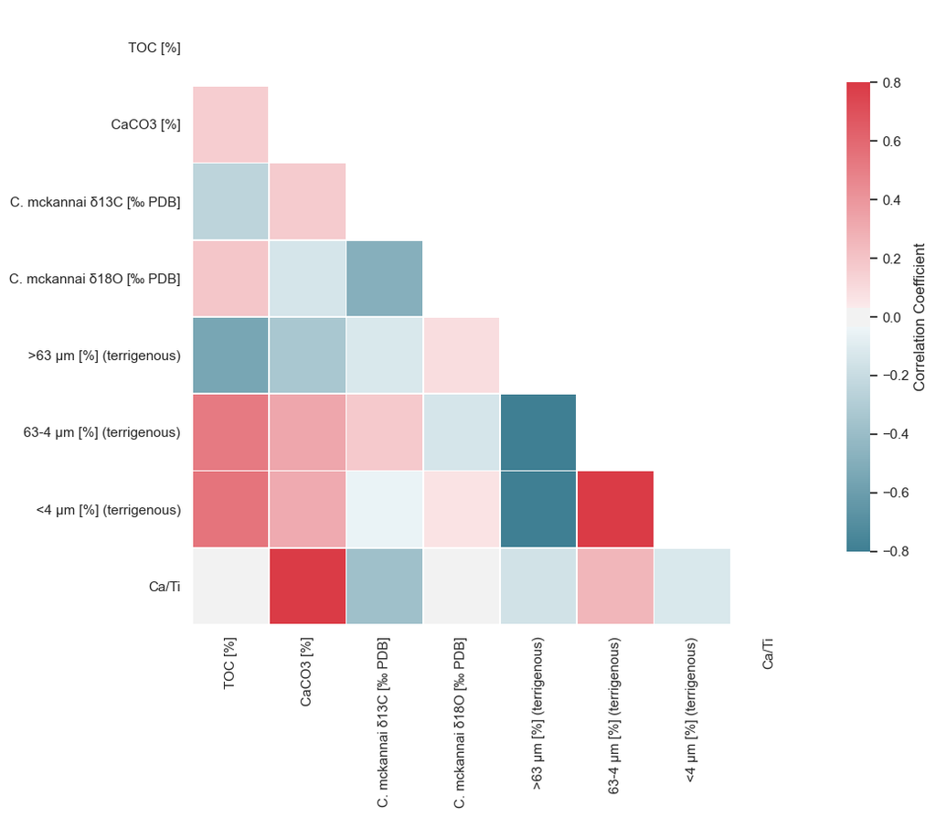

```python
sns.set(style="white")

corr = all_data_norm.iloc[:,2:].corr() # calculate correlation coefficient
mask = np.triu(np.ones_like(corr, dtype=np.bool)) # generate mask for top right triangle
f, ax = plt.subplots(figsize=(11, 9))
cmap = sns.diverging_palette(220, 10, as_cmap=True)

sns.heatmap(corr, mask=mask, cmap=cmap, center=0, square=True, linewidths=.5, vmax=0.8, vmin=-0.8, cbar_kws={"shrink":.75})
ax.collections[0].colorbar.set_label("Correlation Coefficient")
```

### Multiple Scatter Plots

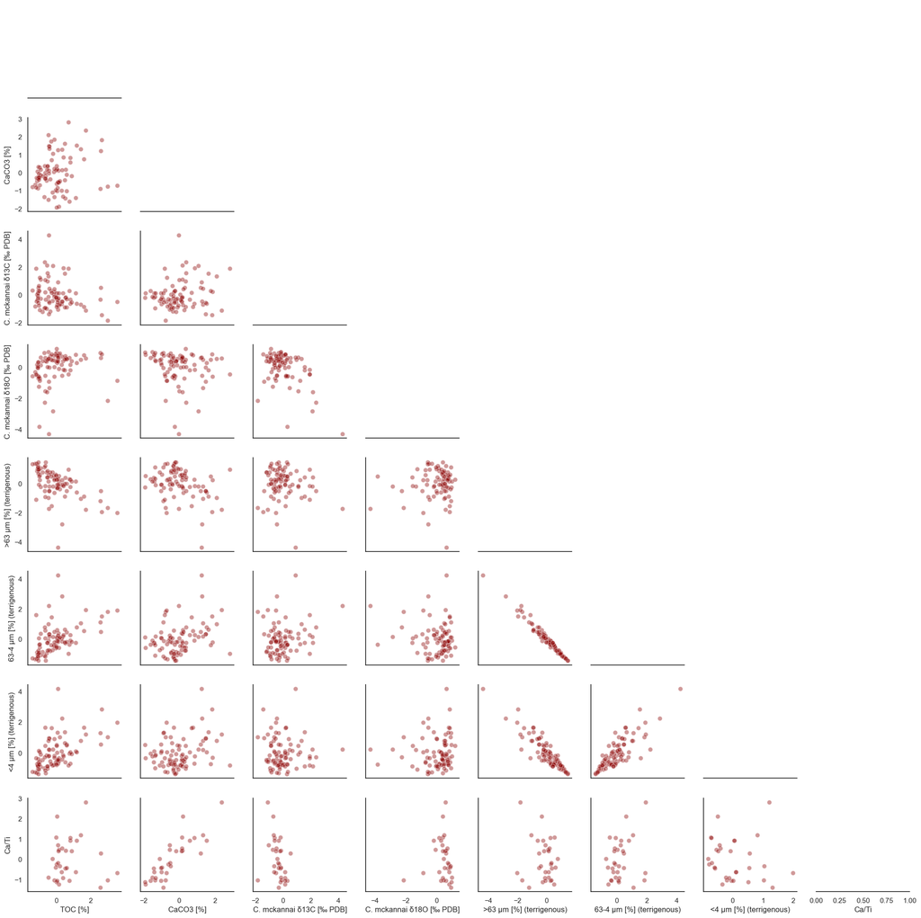

```python
sns.set_context('paper',font_scale=1.5)
sns.set(style='white')

g = sns.PairGrid(all_data_norm.iloc[:,2:], corner=True)
g.map_lower(sns.scatterplot, color="darkred", alpha=0.4, s=50)

def hide_current_axis(*args, **kwds):
    plt.gca().set_visible(False)
    plt.gca().axes.set_axis_off()


g.map_diag(hide_current_axis)
```

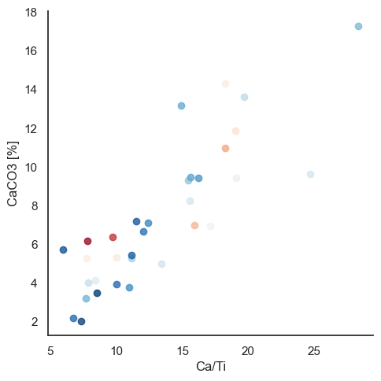

```python
# Use the 'hue' argument to provide a factor variable
sns.lmplot( x="Ca/Ti", y="CaCO3 [%]", data=all_data, fit_reg=False, hue=all_data.columns[5], legend=False, palette="RdBu")
```